# HW4_Sabrina_Zhang

Author

Sabrina_Zhang

## Question 1. Faster row totals

```r
library(microbenchmark)
library(parallel)
library(dplyr)
library(ggplot2)
library(knitr)

# Original function
fun1 <- function(mat) {
  n <- nrow(mat)
  ans <- double(n)
  for (i in 1:n) {
    ans[i] <- sum(mat[i, ])
  }
  ans
}

# Use the built-in function
fun1alt <- function(mat) {
  rowSums(mat)
}

set.seed(2315)
dat <- matrix(rnorm(200 * 100), nrow=200)

all.equal(fun1(dat),fun1alt(dat))
```

```
[1] TRUE
```

```r
length(fun1alt(dat))
```

```
[1] 200
```

```r
bench1 <- microbenchmark(
  Original=fun1(dat),
  Alternative=fun1alt(dat),
  times=100)
kable(summary(bench1,unit="ms")[,c("expr","median","mean")],
  digits=4,col.names=c("Function","Median (ms)","Mean (ms)"),
  caption="Table 1. Row-total runtimes over 100 calls per function.")
```

Table 1. Row-total runtimes over 100 calls per function.

| Function | Median (ms) | Mean (ms) |
| --- | --- | --- |
| Original | 0.5368 | 0.5818 |
| Alternative | 0.0915 | 0.1013 |

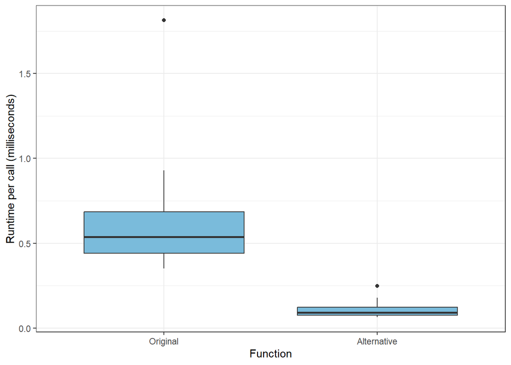

```r
ggplot(as.data.frame(bench1),aes(expr,time/1e6)) +
  geom_boxplot(fill="#7ABBDB") +
  labs(x="Function",y="Runtime per call (milliseconds)") +
  theme_bw()
```

*Figure 1. Runtime distributions for the original and alternative row-total functions.*

Both functions return the same values in a vector of length 200. The alternative uses rowSums() instead of a row loop and has a lower median runtime across 100 calls.

## Question 2. Faster cumulative row totals

```r
# Original function
fun2 <- function(mat) {
  n <- nrow(mat)
  k <- ncol(mat)
  ans <- mat
  for (i in 1:n) {
    for (j in 2:k) {
      ans[i,j] <- mat[i,j] + ans[i,j-1]
    }
  }
  ans
}

# Apply the built-in cumulative sum to each row and restore row orientation.
fun2alt <- function(mat) {
  t(apply(mat,1,cumsum))
}

all.equal(fun2(dat),fun2alt(dat))
```

```
[1] TRUE
```

```r
dim(fun2alt(dat))
```

```
[1] 200 100
```

```r
bench2 <- microbenchmark(
  Original=fun2(dat),
  Alternative=fun2alt(dat),
  times=100)
kable(summary(bench2,unit="ms")[,c("expr","median","mean")],
  digits=4,col.names=c("Function","Median (ms)","Mean (ms)"),
  caption="Table 2. Cumulative-row-total runtimes over 100 calls per function.")
```

Table 2. Cumulative-row-total runtimes over 100 calls per function.

| Function | Median (ms) | Mean (ms) |
| --- | --- | --- |
| Original | 2.4681 | 2.6905 |
| Alternative | 1.1323 | 1.2660 |

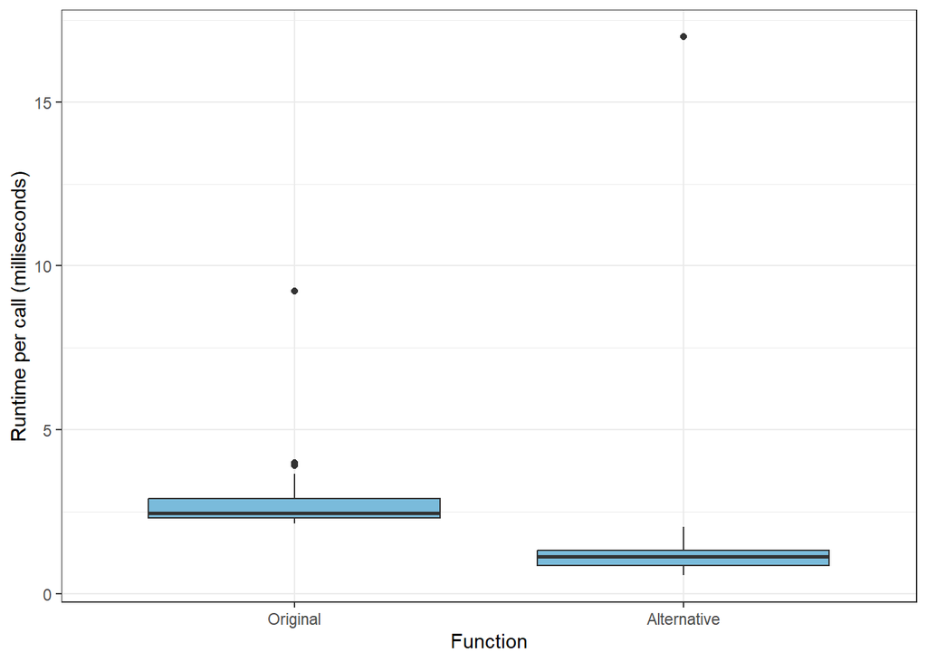

```r
ggplot(as.data.frame(bench2),aes(expr,time/1e6)) +
  geom_boxplot(fill="#7ABBDB") +
  labs(x="Function",y="Runtime per call (milliseconds)") +
  theme_bw()
```

*Figure 2. Runtime distributions for the original and alternative cumulative-row-total functions.*

Both functions return the same values in a 200-by-100 matrix. The alternative calculates each row’s cumulative sums with cumsum() and uses t() to preserve the matrix layout. Table 2 and Figure 2 show that alternative one runs faster.

## Question 3. Parallel estimation of pi

```r
sim_pi <- function(n=1000,i=NULL) {
  p <- matrix(runif(n*2),ncol=2)
  mean(rowSums(p^2)<1)*4
}

# Serial
set.seed(1231)
serial_time <- system.time({
  ans_serial <- unlist(lapply(1:4000,sim_pi,n=10000))
  print(mean(ans_serial))
})
```

```
[1] 3.14124
```

```r
# Include cluster setup, simulation, and shutdown in one timed run
parallel_time <- system.time({
  cl <- makeCluster(6)
  clusterSetRNGStream(cl,1231)
  ans_parallel <- unlist(parLapply(cl,1:4000,sim_pi,n=10000))
  print(mean(ans_parallel))
  stopCluster(cl)
})
```

```
[1] 3.141734
```

```r
pi_results <- data.frame(
  Method=rep(c("Serial","Parallel"),each=4000),
  Estimate=c(ans_serial,ans_parallel))
pi_summary <- pi_results |>
  group_by(Method) |>
  summarise(Mean=mean(Estimate),SD=sd(Estimate),
            Minimum=min(Estimate),Maximum=max(Estimate),.groups="drop")
kable(pi_summary,digits=4,
  caption="Table 3. Distribution of the 4,000 pi estimates from each method.")
```

Table 3. Distribution of the 4,000 pi estimates from each method.

| Method | Mean | SD | Minimum | Maximum |
| --- | --- | --- | --- | --- |
| Parallel | 3.1417 | 0.0163 | 3.0820 | 3.1964 |
| Serial | 3.1412 | 0.0162 | 3.0836 | 3.1960 |

I used six workers to run 4,000 simulations in parallel, with 10,000 points per simulation.

The mean estimates are 3.1412 for the serial method and 3.1417 for the parallel method, both close to pi. The two methods produce similar ranges and standard deviations.

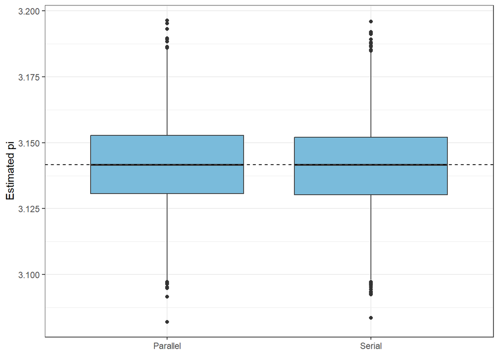

```r
ggplot(pi_results,aes(Method,Estimate)) +
  geom_boxplot(fill="#7ABBDB") +
  geom_hline(yintercept=pi,linetype="dashed") +
  labs(x=NULL,y="Estimated pi") +
  theme_bw()
```

*Figure 3. Ranges and central distributions of pi estimates. The dashed line marks the mathematical constant pi.*

```r
runtime <- data.frame(
  Method=c("Serial","Parallel"),
  Elapsed=c(serial_time[["elapsed"]],parallel_time[["elapsed"]]))
kable(runtime,digits=3,
  col.names=c("Method","Elapsed time (seconds)"),
  caption="Table 4. Complete elapsed times, including parallel cluster setup and shutdown.")
```

Table 4. Complete elapsed times, including parallel cluster setup and shutdown.

| Method | Elapsed time (seconds) |
| --- | --- |
| Serial | 2.75 |
| Parallel | 2.04 |

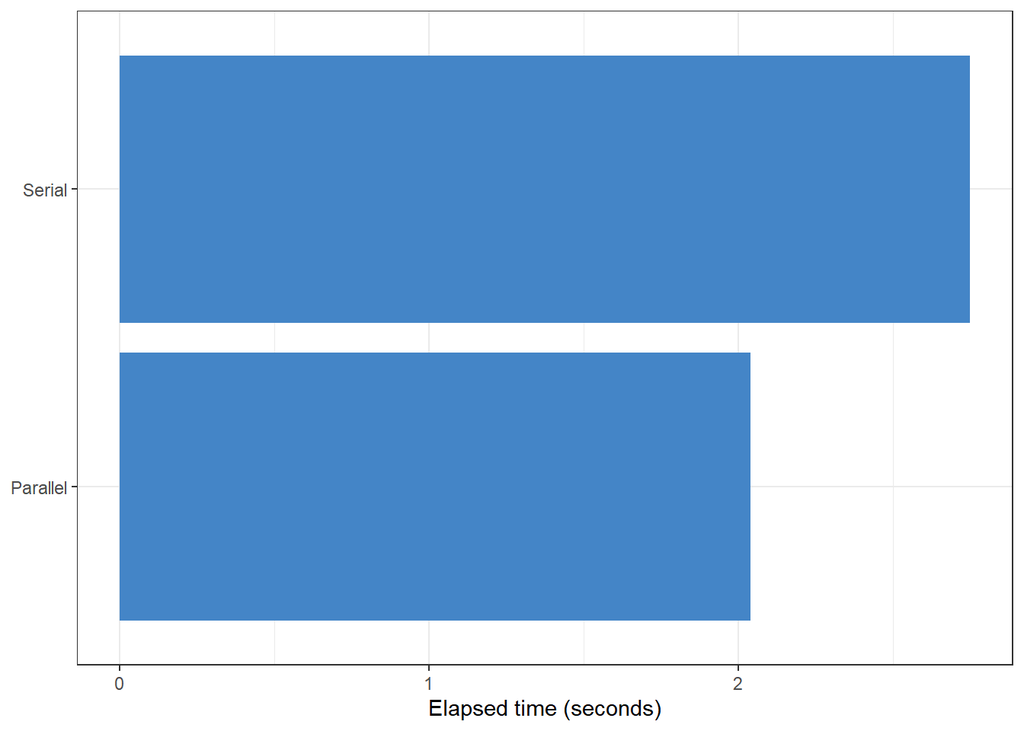

```r
ggplot(runtime,aes(Method,Elapsed)) +
  geom_col(fill="#4485C7") +
  labs(x=NULL,y="Elapsed time (seconds)") +
  coord_flip() +
  theme_bw()
```

*Figure 4. Complete serial and parallel runtimes, including parallel cluster setup and shutdown.*

Table 4 and Figure 4 show that the parallel version is faster in this run, including cluster setup and shutdown.

## Question 4. Number of movies by rating

```r
library(RSQLite)
library(DBI)

con <- dbConnect(SQLite(),":memory:")
film <- read.csv("https://raw.githubusercontent.com/ivanceras/sakila/master/csv-sakila-db/film.csv")
film_category <- read.csv("https://raw.githubusercontent.com/ivanceras/sakila/master/csv-sakila-db/film_category.csv")
category <- read.csv("https://raw.githubusercontent.com/ivanceras/sakila/master/csv-sakila-db/category.csv")

dbWriteTable(con,"film",film)
dbWriteTable(con,"film_category",film_category)
dbWriteTable(con,"category",category)
```

```sql
SELECT rating AS rating_label, COUNT(*) AS titles_in_rating
FROM film
GROUP BY rating
ORDER BY rating;
```

5 records

| rating_label | titles_in_rating |
| --- | --- |
| G | 180 |
| NC-17 | 210 |
| PG | 194 |
| PG-13 | 223 |
| R | 195 |

The counts are G: 180, NC-17: 210, PG: 194, PG-13: 223, and R: 195. PG-13 has the most movies, and G has the fewest.

## Question 5. Average replacement cost and rental rate by rating

```sql
SELECT rating AS rating_label,
       ROUND(AVG(replacement_cost),2) AS replacement_price_mean,
       ROUND(AVG(rental_rate),2) AS rental_price_mean
FROM film
GROUP BY rating
ORDER BY rating;
```

5 records

| rating_label | replacement_price_mean | rental_price_mean |
| --- | --- | --- |
| G | 20.12 | 2.91 |
| NC-17 | 20.14 | 2.97 |
| PG | 18.96 | 3.05 |
| PG-13 | 20.40 | 3.03 |
| R | 20.23 | 2.94 |

PG-13 has the highest average replacement cost ($20.40), and PG has the lowest ($18.96). PG has the highest average rental rate ($3.05), and G has the lowest ($2.91).

## Question 6. Number of films by category ID

```sql
SELECT genre_link.category_id AS genre_identifier,
       COUNT(*) AS titles_in_genre
FROM film AS catalog_title
INNER JOIN film_category AS genre_link
  ON catalog_title.film_id=genre_link.film_id
GROUP BY genre_link.category_id
ORDER BY genre_link.category_id;
```

16 records

| genre_identifier | titles_in_genre |
| --- | --- |
| 1 | 64 |
| 2 | 66 |
| 3 | 60 |
| 4 | 57 |
| 5 | 58 |
| 6 | 68 |
| 7 | 62 |
| 8 | 69 |
| 9 | 73 |
| 10 | 61 |
| 11 | 56 |
| 12 | 51 |
| 13 | 63 |
| 14 | 61 |
| 15 | 74 |
| 16 | 57 |

The 16 categories contain 1,000 films. Category 15 has the most (74), and category 12 has the fewest (51). The check below identifies films without a category record.

```sql
SELECT catalog_title.film_id AS title_without_genre
FROM film AS catalog_title
LEFT JOIN film_category AS genre_link
  ON catalog_title.film_id=genre_link.film_id
WHERE genre_link.film_id IS NULL
ORDER BY catalog_title.film_id;
```

2 records

| title_without_genre |
| --- |
| 1001 |
| 1002 |

Film IDs 1001 and 1002 have no category record, explaining the difference from the 1,002 films in Question 4.

## Question 7. Name of the most popular category

```sql
SELECT genre_lookup.name AS leading_genre,
       COUNT(*) AS catalog_title_total
FROM film AS catalog_title
INNER JOIN film_category AS genre_link
  ON catalog_title.film_id=genre_link.film_id
INNER JOIN category AS genre_lookup
  ON genre_link.category_id=genre_lookup.category_id
GROUP BY genre_lookup.category_id,genre_lookup.name
ORDER BY catalog_title_total DESC
LIMIT 1;
```

1 records

| leading_genre | catalog_title_total |
| --- | --- |
| Sports | 74 |

Sports is the most popular category by number of films, with 74 films.

```r
dbDisconnect(con)
```